# Data Simulation Project

Hung Do

May 22, 2017

Title: Data Simulation of a Research about the Relationship between BMI and Energy-Dense Snack Food Intake

Reference: Energy-Dense Snack Food Intake in Adolescence: Longitudinal Relationship to Weight and Fatness https://www.ncbi.nlm.nih.gov/pubmed/15044663

Background: The research analyzed data from the Massachusetts Institute of Technology Growth and Development Study.It enrolled 196 nonobese premenarcheao girls with age from 8-12 between 1990 and 1993. They were followed until 4 years after menarche. The data was collected annually including: Age, BMI, percentage body fat (%BF), TV viewing, Activity and Inactivity time, Daily kilocalories, and EDS food consumption (baked goods, ice cream, chips, sugar-sweetened soda, and candy).

Results: “Linear mixed effects modeling indicated no relationship between BMI z-score or Percent Body Fat and total EDS food consumption. Soda was the only EDS food that was significantly related to BMI z score over the 10-year study period, but it was not related to %BF. In addition, a significant, positive relationship was observed between EDS food consumption and television viewing.”

Simulation Approach: Recreate data using mean, SD, and median provided by the study. Check for correct relationships between variables Statistical test Fit linear regression model.

Simulation entry data of the study

```r
set.seed = 99

simulate_entry <- function(N){
  Age <- rnorm(N, 10, 0.93)
  BMI <- rnorm(N, 16.6, 1.8)
  #
  BMI_z_score <- rnorm(N,-0.27, 0.89)
  #
  P_body_fat <- rnorm(N, 23.4, 4.7)
  #
  TV_low <- runif(N/2, min = 0, max = 3)
  TV_high <- runif(N/2, min = 3, max = 8.05)
  TV <- c(TV_low, TV_high)
  #
  Inactivity_time <- rnorm(N, 19.9, 1.6)
  Activity_time <- 24 - Inactivity_time    # Total is 24h
  #
  Daily_kilocalories <- rnorm(N, 2021, 669)
  #
  P_cal_fat <- rnorm(N, 30.1, 5.3)
  P_cal_protein <- rnorm(N, 15.6, 3)
  P_cal_carbohydrates <- 100 - P_cal_protein - P_cal_fat  # Total is 100%
  #
  EDS_low <- runif(N/2, min = 0 , max = 1.86)
  EDS_high <- runif(N/2, min = 1.86, max = 5.5)
  EDS_food <- c(EDS_low, EDS_high)   # servings/day
  #
  P_kcal_EDS_low <- runif(N/2, min = 0, max = 14.5)
  P_kcal_EDS_high <- runif(N/2, min = 14.5, max = 34)
  P_kcal_EDS <- c(P_kcal_EDS_low, P_kcal_EDS_high)
  #
  P_kcal_baked_goods_low <- runif(N/2, min = 0, max = 3.4)
  P_kcal_baked_goods_high <- runif(N/2, min = 3.4, max = 7)
  P_kcal_baked_goods <- c(P_kcal_baked_goods_low, P_kcal_baked_goods_high)
  #
  P_kcal_ice_scream_low <- runif(N/2, min = 0, max = 3)
  P_kcal_ice_scream_high <- runif(N/2, min = 3, max = 8.5)
  P_kcal_ice_scream <- c(P_kcal_ice_scream_low, P_kcal_ice_scream_high)
  #
  P_kcal_chips_low <- runif(N/2, min = 0, max = 1.5)
  P_kcal_chips_high <- runif(N/2, min = 1.5, max = 5.8)
  P_kcal_chips <- c(P_kcal_chips_low, P_kcal_chips_high)
  #
  P_kcal_soda_low <- runif(N/2, min = 0, max = 1.6)
  P_kcal_soda_high <- runif(N/2, min = 1.6, max = 7.7)
  P_kcal_soda <- c(P_kcal_soda_low, P_kcal_soda_high)
  #
  P_kcal_candy_low <- runif(N/2, min = 0, max = 2.6)
  P_kcal_candy_high <- runif(N/2, min = 2.6, max = 8.75)
  P_kcal_candy <- c(P_kcal_candy_low, P_kcal_candy_high)
  #
  data.frame(Age,BMI,BMI_z_score,P_body_fat,TV,Activity_time,Inactivity_time,
             Daily_kilocalories,P_cal_fat,P_cal_protein,P_cal_carbohydrates,
             EDS_food,P_kcal_EDS,P_kcal_baked_goods,P_kcal_ice_scream,
             P_kcal_chips,P_kcal_soda,P_kcal_candy)
}
Entry_data <- simulate_entry(166)
```

Simulate exit data of the study

```r
simulate_exit <- function(N){
  Age <- rnorm(N, 16.9, 1)
  BMI <- rnorm(N, 21.4, 2.5)
  #
  BMI_z_score_low <- runif(N/2, min = -0.15, max = 0.07)
  BMI_z_score_high <- runif(N/2, min = 0.07, max = 0.1)
  BMI_z_score <- c(BMI_z_score_low, BMI_z_score_high)
  #
  P_body_fat <- rnorm(N, 27.6, 3.8)
  #
  TV_low <- runif(N/2, min = 0, max = 1.4)
  TV_high <- runif(N/2, min = 1.4, max = 4.5)
  TV <- c(TV_low, TV_high)
  #
  Inactivity_time <- rnorm(N, 20.3, 1.8)
  Activity_time <- 24 - Inactivity_time    # Total is 24h
  #
  Daily_kilocalories <- rnorm(N, 1723, 655)
  #
  P_cal_fat <- rnorm(N, 27.9, 6.2)
  P_cal_protein <- rnorm(N, 16.3, 3.4)
  P_cal_carbohydrates <- 100 - P_cal_protein - P_cal_fat  # Total is 100%
  #
  EDS_low <- runif(N/2, min = 0 , max = 1.7)
  EDS_high <- runif(N/2, min = 1.7, max = 4.7)
  EDS_food <- c(EDS_low, EDS_high)   # servings/day
  #
  P_kcal_EDS_low <- runif(N/2, min = 0, max = 14.2)
  P_kcal_EDS_high <- runif(N/2, min = 14.2, max = 34)
  P_kcal_EDS <- c(P_kcal_EDS_low, P_kcal_EDS_high)
  #
  P_kcal_baked_goods_low <- runif(N/2, min = 0, max = 2.9)
  P_kcal_baked_goods_high <- runif(N/2, min = 2.9, max = 8)
  P_kcal_baked_goods <- c(P_kcal_baked_goods_low, P_kcal_baked_goods_high)
  #
  P_kcal_ice_scream_low <- runif(N/2, min = 0, max = 2.5)
  P_kcal_ice_scream_high <- runif(N/2, min = 2.5, max = 7.3)
  P_kcal_ice_scream <- c(P_kcal_ice_scream_low, P_kcal_ice_scream_high)
  #
  P_kcal_chips_low <- runif(N/2, min = 0, max = 1)
  P_kcal_chips_high <- runif(N/2, min = 1, max = 3.7)
  P_kcal_chips <- c(P_kcal_chips_low, P_kcal_chips_high)
  #
  P_kcal_soda_low <- runif(N/2, min = 0, max = 2.5)
  P_kcal_soda_high <- runif(N/2, min = 2.5, max = 10.85)
  P_kcal_soda <- c(P_kcal_soda_low, P_kcal_soda_high)
  #
  P_kcal_candy_low <- runif(N/2, min = 0, max = 3.1)
  P_kcal_candy_high <- runif(N/2, min = 3.1, max = 8.7)
  P_kcal_candy <- c(P_kcal_candy_low, P_kcal_candy_high)
  #
  data.frame(Age,BMI,BMI_z_score,P_body_fat,TV,Activity_time,Inactivity_time,
             Daily_kilocalories,P_cal_fat,P_cal_protein,P_cal_carbohydrates,
             EDS_food,P_kcal_EDS,P_kcal_baked_goods,P_kcal_ice_scream,
             P_kcal_chips,P_kcal_soda,P_kcal_candy)
}
Exit_data <- simulate_exit(142) #cannot run odd numbers because rounding of runif(N/2)
```

Check relationship between variables: Relationships between entry data

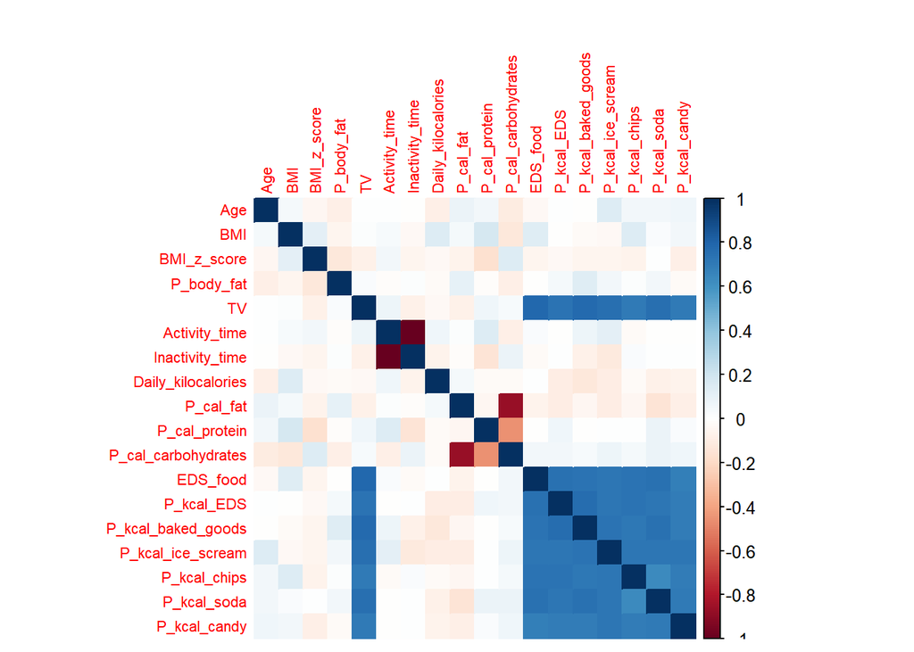

```r
library(corrplot)
M <- cor(Entry_data)
corrplot(M, mar=c(0.5,1,2,3), tl.offset = 0.3, tl.cex = 0.7, method="color", bg = "black")
```

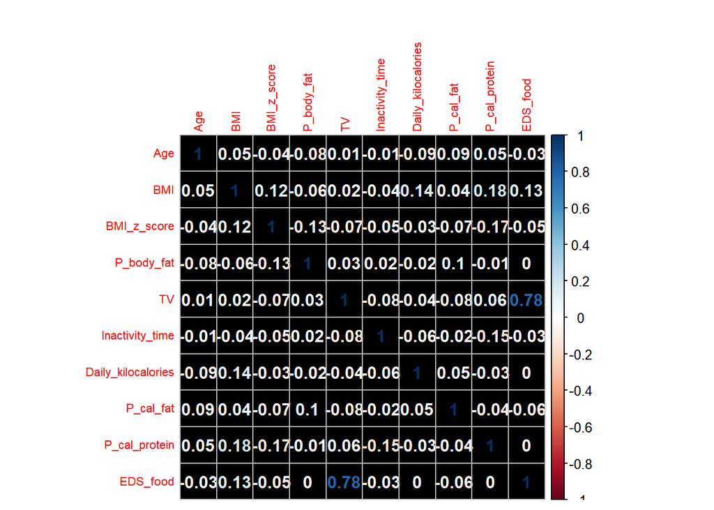

```r
# corrplot(M, mar=c(0.5,1,2,3), tl.offset = 0.3, tl.cex = 0.7, method="number", bg = "black") #can't view
# remove highly correlated variables - activity time and P_cal_carbohydrate
Entry_data_1 <- Entry_data[,-c(6,11,13:18)]
N <- cor(Entry_data_1)
corrplot(N, mar=c(0.5,1,2,3), tl.offset = 0.3, tl.cex = 0.7, method="number", bg = "black")
```

```r
# TV is postively correlated to EDS food
```

Relationships between exit data

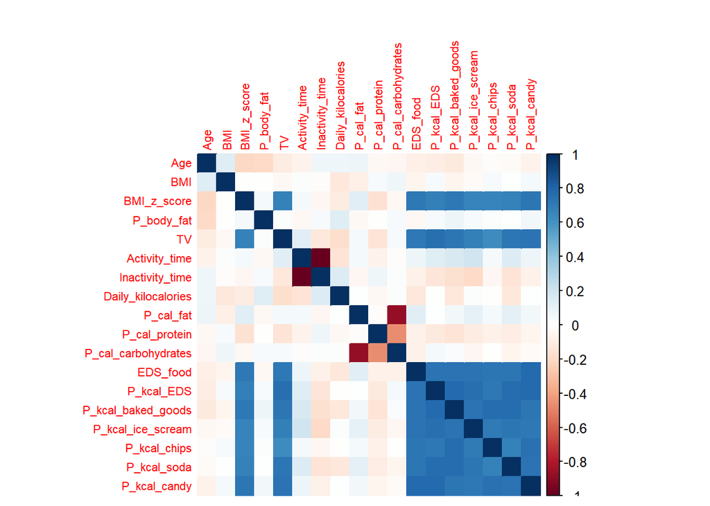

```r
O <- cor(Exit_data)
corrplot(O, mar=c(0.5,1,2,3), tl.offset = 0.3, tl.cex = 0.7, method="color", bg = "black")
```

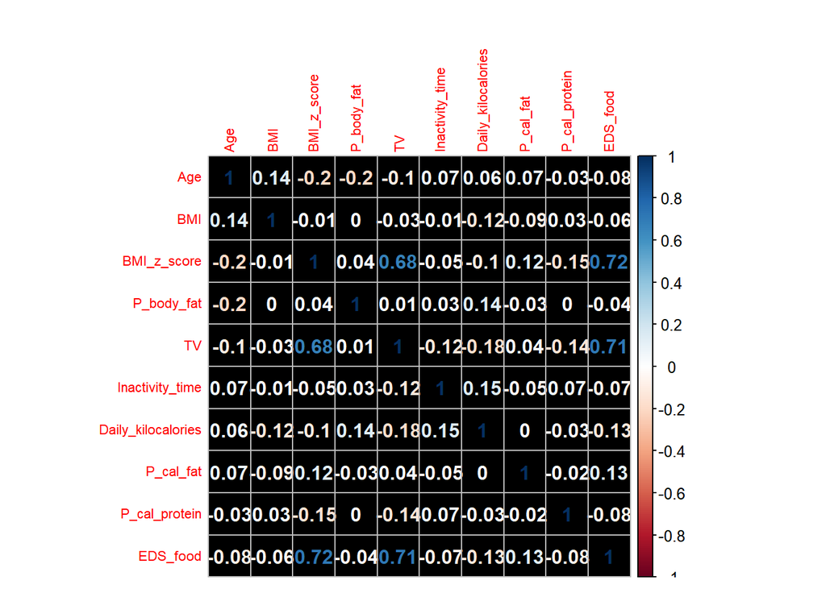

```r
Exit_data_1 <- Exit_data[,-c(6,11,13:18)]
P <- cor(Exit_data_1)
corrplot(P, mar=c(0.5,1,2,3), tl.offset = 0.3, tl.cex = 0.7, method="number", bg = "black")
```

```r
# TV, EDS food, and BMI_z_score are postively correlated
```

Wilcoxon Signed-Rank Test The Wilcoxon signed rank test has the null hypothesis that both samples are from the same population.  
The Wilcoxon test creates a pooled ranking of all observed differences between the two dependent measurements.  
It uses the standard normal distributed z-value to test of significance.

```r
Entry_data_paired <- Entry_data[sample(nrow(Entry_data), 132), ]  #Randomly pick 132 obs for paired test
Exit_data_paired <- Exit_data[sample(nrow(Exit_data), 132), ]

wilcox.test(Entry_data_paired$Age, Exit_data_paired$Age, paired=TRUE) #V = 0, p-value < 2.2e-16 (similar to the paper)
```

```
##
##  Wilcoxon signed rank test with continuity correction
##
## data:  Entry_data_paired$Age and Exit_data_paired$Age
## V = 0, p-value < 2.2e-16
## alternative hypothesis: true location shift is not equal to 0
```

```r
wilcox.test(Entry_data_paired$BMI, Exit_data_paired$BMI, paired=TRUE) #V = 98, p-value < 2.2e-16 (similar to the paper)
```

```
##
##  Wilcoxon signed rank test with continuity correction
##
## data:  Entry_data_paired$BMI and Exit_data_paired$BMI
## V = 70, p-value < 2.2e-16
## alternative hypothesis: true location shift is not equal to 0
```

```r
wilcox.test(Entry_data_paired$BMI_z_score, Exit_data_paired$BMI_z_score, paired=TRUE) #V = 1995, p-value = 5.44e-08 (similar to the paper)
```

```
##
##  Wilcoxon signed rank test with continuity correction
##
## data:  Entry_data_paired$BMI_z_score and Exit_data_paired$BMI_z_score
## V = 2926, p-value = 0.0008946
## alternative hypothesis: true location shift is not equal to 0
```